# *Bicycle-sharing system*

# step 3

**Compare different fields of data to see what data we will use in our analysis**

```python
#to see our data values and structure


data_files = ['C:\\Users\\zas\\Downloads\\bike share project\\bikesharedata2017\\Washington.csv',
              'C:\\Users\\zas\\Downloads\\bike share project\\bikesharedata2017\\NYC.csv',
              'C:\\Users\\zas\\Downloads\\bike share project\\bikesharedata2017\\Chicago.csv']
example_trips = {}
for data_file in data_files:
    city, first_trip = print_first_point(data_file)
    example_trips[city] = first_trip
```

[output not shown]

# Observations

> *We have here 9 same data fields but with different data structure*  
> We will use only 4 same fields of this fields in our comparison but other 5 filled will be useful if we go in depth  
> *We start to uniform data*  
> First in trip duration as we have in NYC it measured in second and Chicago and Washington also so we need to convert them to minutes and change trip duration formate  
> *change date and time format*  
> unify user type for the system and change its formate

# Posing Questions

#### how many trips are made by different types of users?

#### what are the ranke of cities according to user types?

#### Which city has the highest number of trips?

#### what is the proportion of subciber user type of the total trips ?

#### what is the proportion of customer user type of the total trips ?

#### Which city has the highest proportion of trips made by short-term customers?

#### what is the average time of trip duration for each city ?

#### what are the Percentage of trips that are longer than 30 minutes?

#### what is the average trip length for Subscribers and Customers in each city?

#### who take longer rides - Subscribers or Customers in each city?

# Condensing the Trip_Data

1. bulding up helper fuctions to uniform and prepare our data for comparision  
2. condensata data after manipulation and get 3 summary files for every bike sys

# Duration manipulation

**duration as we have in NYC it measured in second , Chicago and Washington also so we need to convert them to minutes and change trip duration formate**

```python
def duration_in_mins(datum, city):
    if city == 'Washington':
        while True:
            try:
                duration = (float(datum['Duration'])/60)
                return duration
            except ValueError:
                return float(0.0)
    elif city == 'NYC' :
        while True:
            try:
                duration=(float(datum['Trip Duration'])/60)
                return duration
            except ValueError:
                return float(0.0)
    elif city == 'Chicago' :
        while True:
            try:
                if datum['tripduration'] is not None:
                    duration= (float(datum['tripduration'])/60)
                    return float(duration)
            except ValueError:
                return float(0.0)
    else:
         return float(0.0)
```

# Date and Time manipulation

**change date and time format**

```python
def time_of_trip(datum, city):

    while True:
        try:
            if city == 'Washington':
                month = int(datetime.datetime.strptime(datum['Start date'],"%Y-%m-%d %H:%M:%S").strftime('%m'))
                hour= int(datetime.datetime.strptime(datum['Start date'],"%Y-%m-%d %H:%M:%S").strftime('%H'))
                day_of_week = datetime.datetime.strptime(datum['Start date'],"%Y-%m-%d %H:%M:%S").strftime('%A')
                return (month,hour,day_of_week)
            elif city == 'NYC':
                month = int(datetime.datetime.strptime(datum['Start Time'],"%Y-%m-%d %H:%M:%S").strftime('%m'))
                hour = int(datetime.datetime.strptime(datum['Start Time'],"%Y-%m-%d %H:%M:%S").strftime('%H'))
                day_of_week = datetime.datetime.strptime(datum['Start Time'],"%Y-%m-%d %H:%M:%S").strftime('%A')
                return (month,hour,day_of_week)
            elif city == 'Chicago':
                month = int(datetime.datetime.strptime(datum['start_time'],"%m/%d/%Y %H:%M:%S").strftime('%m'))
                hour= int(datetime.datetime.strptime(datum['start_time'],"%m/%d/%Y %H:%M:%S").strftime('%H'))
                day_of_week = datetime.datetime.strptime(datum['start_time'],"%m/%d/%Y  %H:%M:%S").strftime('%A')
                return (month,hour,day_of_week)
            else:
                return ('Invalid City')
        except (ValueError,TypeError,StopIteration):
            return 0.0
```

# User Type manipulation

**unify user type for the system and change its formate**

```python
def type_of_user(datum, city ):
    if city == 'Washington':
        if datum['Member type'] == 'Member':
            datum['Member type']='Subscriber'
            user_type= datum['Member type']
            return user_type
        elif datum['Member type'] == 'Casual':
            datum['Member Type'] ='Customer'
            user_type = datum['Member Type']
            return user_type
        else:
            print("Invalid Member Type for Washington")
    elif city == 'Chicago':
        user_type =datum['usertype']
        return user_type
    elif city == 'NYC':
        user_type = datum['User Type']
        return user_type
    else:
        print("Invalid Member Type")
```

```python
import csv

def condense_data(in_file, out_file):
    with open(out_file, 'w',newline="") as f_out, open(in_file, 'r') as f_in:
        out_colnames = ['duration', 'month', 'hour', 'day_of_week', 'user_type']
        trip_writer = csv.DictWriter(f_out, fieldnames = out_colnames,delimiter=',')
        trip_writer.writeheader()
        trip_reader = csv.DictReader(f_in,delimiter=',', quotechar='"', quoting=csv.QUOTE_ALL,lineterminator='\n')
        for row in trip_reader:
            new_point = {}
            new_point['duration'] = duration_in_mins(row, city)
            new_point['user_type'] = type_of_user(row, city)
            try:
                new_point['month'],new_point['hour'],new_point['day_of_week'] = time_of_trip(row, city)
            except (TypeError):
                print('cannot unpack non-iterable float object')
            trip_writer.writerow(new_point)
```

**first_trip as ex.**

```python
city_info = {'Washington': {'in_file': 'C:\\Users\\zas\\Downloads\\bike share project\\bikesharedata2017\\Washington.csv',
                                    'out_file': 'C:\\Users\\zas\\Downloads\\bike share project\\bikesharedata2017\\Washington summary 2017.csv'},
            'NYC': {'in_file': 'C:\\Users\\zas\\Downloads\\bike share project\\bikesharedata2017\\NYC.csv',
                              'out_file': 'C:\\Users\\zas\\Downloads\\bike share project\\bikesharedata2017\\NYC summary 2017.csv'},
            'Chicago': {'in_file': 'C:\\Users\\zas\\Downloads\\bike share project\\bikesharedata2017\\Chicago.csv',
                                    'out_file': 'C:\\Users\\zas\\Downloads\\bike share project\\bikesharedata2017\\Chicago summary 2017.csv'}}





for city, filename in city_info.items():

    condense_data(filename['in_file'], filename['out_file'])
    print_first_point(filename['out_file'])
```

[output not shown]

# Exploratory Data Analysis

# Statistics

## what is the rank of each city according to number of trips and types of users?

**how many trips are made by different types of users?**

```python
import csv

def number_of_trips(filename):
    with open(filename, 'r') as f_in:
        reader = csv.DictReader(f_in)
        n_subscribers = 0
        n_customers = 0
        n_total = n_subscribers + n_customers
        for row in reader:
            if row['user_type'] == 'Subscriber':
                n_subscribers += 1
            else:
                n_customers += 1
        n_total = n_subscribers + n_customers

    return(n_subscribers, n_customers, n_total)


data_file_Washington = 'C:\\Users\\zas\\Downloads\\bike share project\\bikesharedata2017\\Washington summary 2017.csv'
data_file_Chicago = 'C:\\Users\\zas\\Downloads\\bike share project\\bikesharedata2017\\Chicago summary 2017.csv'
data_file_NYC = 'C:\\Users\\zas\\Downloads\\bike share project\\bikesharedata2017\\NYC summary 2017.csv'
a =number_of_trips(data_file_NYC)
print(a)
```

```
(278781, 16159, 294940)
```

**what are the ranke of cities according to user types?**

```python
trips_data = {'Washington': {'Subscribers':0, 'Customers':0, 'Total':0},
             'Chicago': {'Subscribers':0, 'Customers':0, 'Total':0},
             'NYC': {'Subscribers':0, 'Customers':0, 'Total':0}}


trips_data['Washington'] = dict(zip(trips_data['Washington'].keys(), number_of_trips(data_file_Washington)))
trips_data['Chicago'] = dict(zip(trips_data['Chicago'].keys(), number_of_trips(data_file_Chicago)))
trips_data['NYC'] = dict(zip(trips_data['NYC'].keys(), number_of_trips(data_file_NYC)))

cities_dict = {1:'Washington' , 2:'Chicago' , 3:'NYC' }
print(cities_dict)


total_trips_dict = {1:trips_data['Washington']['Total'],
                    2:trips_data['Chicago']['Total'],
                    3:trips_data['NYC']['Total']}
```

```
{1: 'Washington', 2: 'Chicago', 3: 'NYC'}
```

**Which city has the highest number of trips?**

```python
city_high_trips = max(total_trips_dict, key=total_trips_dict.get)
print("\nWhich city has the highest number of trips?" + " => " + cities_dict[city_high_trips])
print('total :',total_trips_dict)
```

```
Which city has the highest number of trips? => Chicago
total : {1: 3757781, 2: 3828844, 3: 294940}
```

**what is the proportion of subciber user type of the total trips ?**

```python
subs_prop_dict = {1: trips_data['Washington']['Subscribers']/trips_data['Washington']['Total'],
                  2: trips_data['Chicago']['Subscribers']/trips_data['Chicago']['Total'],
                  3: trips_data['NYC']['Subscribers']/trips_data['NYC']['Total']}
print('subs :',subs_prop_dict)
```

```
subs : {1: 0.7387282547865349, 2: 0.7814319413379077, 3: 0.9452125856106327}
```

**what is the proportion of customer user type of the total trips ?**

```python
cust_prop_dict = {1: trips_data['Washington']['Customers']/trips_data['Washington']['Total'],
                  2: trips_data['Chicago']['Customers']/trips_data['Chicago']['Total'],
                  3: trips_data['NYC']['Customers']/trips_data['NYC']['Total']}
print('cust :',cust_prop_dict)
#customer proportion of the total trips
```

```
cust : {1: 0.2612717452134651, 2: 0.21856805866209228, 3: 0.05478741438936733}
```

**Which city has the highest proportion of trips made by short-term customers?**

```python
city_high_prob_cust = max(cust_prop_dict, key=cust_prop_dict.get)
print("\nWhich city has the highest proportion of trips made by short-term customers?" + " => " + cities_dict[city_high_prob_cust])
print('city_high_prob_cust:',cust_prop_dict)
```

```
Which city has the highest proportion of trips made by short-term customers? => Washington
city_high_prob_cust: {1: 0.2612717452134651, 2: 0.21856805866209228, 3: 0.05478741438936733}
```

**what is the average time of trip duration for each city ?**

```python
#input data to compare avg trip duration
total_trips_washington = total_trips_dict[1]
total_trips_chicago = total_trips_dict[2]
total_trips_nyc = total_trips_dict[3]
```

```python
def avg_trip_length(filename, city):
    with open(filename, 'r') as f_in:
        reader = csv.DictReader(f_in)
        total_trip_length = 0
        for row in reader:
            total_trip_length = total_trip_length + float(row['duration'])
            if city == 'Washington':
                total_trips = total_trips_washington
            elif city == 'Chicago':
                total_trips = total_trips_chicago
            else:
                total_trips = total_trips_nyc
    return(int(total_trip_length/total_trips))


avg_trip_length_washington = avg_trip_length(data_file_Washington, 'Washington')
avg_trip_length_chicago = avg_trip_length(data_file_Chicago, 'Chicago')
avg_trip_length_nyc = avg_trip_length(data_file_NYC, 'NYC')

print("\n*** Average Trip Length for each City ***\n")
print("Average Trip Length of Washington" + " = " + str(avg_trip_length_washington) + " Minutes")
print("Average Trip Length of Chicago" + " = " + str(avg_trip_length_chicago) + " Minutes")
print("Average Trip Length of NYC" + " = " + str(avg_trip_length_nyc) + " Minutes")
```

```
*** Average Trip Length for each City ***

Average Trip Length of Washington = 19 Minutes
Average Trip Length of Chicago = 15 Minutes
Average Trip Length of NYC = 12 Minutes
```

**what are the Percentage of trips that are longer than 30 minutes?**

```python
def longer_trip_percent(filename, city):
    '''
        Get percent of trips that are longer than 30 minutes
    '''
    TRIP_DURATION = 30.0
    with open(filename, 'r') as f_in:
        reader = csv.DictReader(f_in)
        longer_trip_count = 0
        for row in reader:
            if float(row['duration']) > TRIP_DURATION:
                longer_trip_count += 1
                if city == 'Washington':
                    total_trips = total_trips_washington
                elif city == 'Chicago':
                    total_trips = total_trips_chicago
                else:
                     total_trips = total_trips_nyc
    return((round(longer_trip_count/total_trips, 4) * 100))




long_trip_per_washington = longer_trip_percent(data_file_Washington, 'Washington')
long_trip_per_chicago = longer_trip_percent(data_file_Chicago, 'Chicago')
long_trip_per_nyc = longer_trip_percent(data_file_NYC, 'NYC')

print("\n*** Percentage of trips that are longer than 30 minutes ***\n")
print("Percentage Trips Longer Than 30 Minutes in Washington" + " = " + str(long_trip_per_washington) + "%")
print("Percentage Trips Longer Than 30 Minutes in Chicago" + " = " + str(long_trip_per_chicago) + "%")
print("Percentage Trips Longer Than 30 Minutes in NYC" + " = " + str(long_trip_per_nyc) + "%")
```

```
*** Percentage of trips that are longer than 30 minutes ***

Percentage Trips Longer Than 30 Minutes in Washington = 11.959999999999999%
Percentage Trips Longer Than 30 Minutes in Chicago = 7.960000000000001%
Percentage Trips Longer Than 30 Minutes in NYC = 4.1000000000000005%
```

what is the average trip length for Subscribers and Customers in each city?  
who take longer rides - Subscribers or Customers in each city?

```python
#Average trip length for Subscribers or Customers?
#here to see what type of users are the target for the system to biuld financial deciesion to the right user
def rides_user_type(filename, city):
    '''
        Get the rides based on user type - Subscribers and Customers
    '''
    with open(filename, 'r') as f_in:
        reader = csv.DictReader(f_in)

        trip_length_subscribers = 0
        trip_count_subscribers = 0

        trip_length_customers = 0
        trip_count_customers = 0

        for row in reader:
            if city == 'Washington':
                if row['user_type'] == 'Subscriber':
                    trip_length_subscribers += float(row['duration'])
                    trip_count_subscribers += 1
                else:
                    trip_length_customers += float(row['duration'])
                    trip_count_customers += 1
            elif city == 'Chicago':
                if row['user_type'] == 'Subscriber':
                    trip_length_subscribers += float(row['duration'])
                    trip_count_subscribers += 1
                else:
                    trip_length_customers += float(row['duration'])
                    trip_count_customers += 1
            else:
                if row['user_type'] == 'Subscriber':
                    trip_length_subscribers += float(row['duration'])
                    trip_count_subscribers += 1
                else:
                    trip_length_customers += float(row['duration'])
                    trip_count_customers += 1

        avg_trip_len_subscriber = round((trip_length_subscribers/trip_count_subscribers), 2)
        avg_trip_len_customer = round((trip_length_customers/trip_count_customers), 2)
        return(avg_trip_len_subscriber, avg_trip_len_customer)

avg_trip_len_subs_washington, avg_trip_len_cust_washington = rides_user_type(data_file_Washington, 'Washington')
avg_trip_len_subs_chicago, avg_trip_len_cust_chicago = rides_user_type(data_file_Chicago, 'Chicago')
avg_trip_len_subs_nyc, avg_trip_len_cust_nyc = rides_user_type(data_file_NYC, 'NYC')

print("\n*** Average trip length for Subscribers or Customers? ***\n")
print("For Washington" + " => " + "Subscribers Avg Duration = " + str(avg_trip_len_subs_washington) + "; Customers Avg Duration = " + str (avg_trip_len_cust_washington))
print("For Chicago" + " => " + "Subscribers Avg Duration = " + str(avg_trip_len_subs_chicago) + "; Customers Avg Duration = " + str (avg_trip_len_cust_chicago))
print("For NYC" + " => " + "Subscribers Avg Duration = " + str(avg_trip_len_subs_nyc) + "; Customers Avg Duration = " + str (avg_trip_len_cust_nyc))

print("\n*** Who take longer rides - Subscribers or Customers? ***\n")


if (avg_trip_len_subs_washington > avg_trip_len_cust_washington):
    print ("In Washington Subscribers take longer rides than Customers")
else:
    print ("In Washington Customers take longer rides than Subscribers")

if (avg_trip_len_subs_chicago > avg_trip_len_cust_chicago):
    print ("In Chicago Subscribers take longer rides than Customers")
else:
    print ("In Chicago Customers take longer rides than Subscribers")

if (avg_trip_len_subs_nyc > avg_trip_len_cust_nyc):
    print ("In NYC Subscribers take longer rides than Customers")
else:
    print ("In NYC Customers take longer rides than Subscribers")
```

```
*** Average trip length for Subscribers or Customers? ***

For Washington => Subscribers Avg Duration = 12.16; Customers Avg Duration = 39.2
For Chicago => Subscribers Avg Duration = 11.73; Customers Avg Duration = 30.93
For NYC => Subscribers Avg Duration = 9.22; Customers Avg Duration = 65.94

*** Who take longer rides - Subscribers or Customers? ***

In Washington Customers take longer rides than Subscribers
In Chicago Customers take longer rides than Subscribers
In NYC Customers take longer rides than Subscribers
```

# Visualizations

```python
#here to visualize data

import matplotlib.pyplot as plt
def trip_times(filename, city):
    '''
        Get the trip times for each of the cities.
    '''
    with open(filename, 'r') as f_in:
        reader = csv.DictReader(f_in)
        trip_times_washington = []
        trip_times_chicago = []
        trip_times_nyc = []
        for row in reader:
            if city == 'Washington':
                trip_times_washington.append(float(row['duration']))
            elif city == 'Chicago':
                trip_times_chicago.append(float(row['duration']))
            else:
                trip_times_nyc.append(float(row['duration']))
    if city == 'Washington':
        return trip_times_washington
    elif city == 'Chicago':
        return trip_times_chicago
    else:
        return trip_times_nyc

trip_times_washington = trip_times(data_file_Washington, 'Washington')
trip_times_chicago = trip_times(data_file_Chicago, 'Chicago')
trip_times_nyc = trip_times(data_file_NYC, 'NYC')
```

**histogram for trip time in washington**

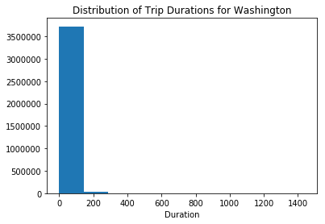

```python
plt.hist(trip_times_washington)
plt.title('Distribution of Trip Durations for Washington')
plt.xlabel('Duration')
plt.show()
```

**histogram for trip time in chicago**

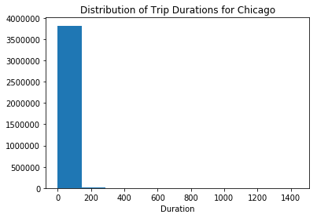

```python
plt.hist(trip_times_chicago)
plt.title('Distribution of Trip Durations for Chicago')
plt.xlabel('Duration')
plt.show()
```

**histogram for trip time in nyc**

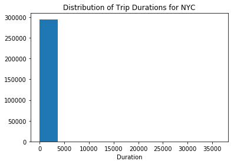

```python
plt.hist(trip_times_nyc)
plt.title('Distribution of Trip Durations for NYC')
plt.xlabel('Duration' )
plt.show()
```

**Type of distribution of trips duration for different types of users?**

```python
#here to see user type & the duration for every type
def trip_times_subs_cust(filename, city):
    '''
        Get the trip times for each of the cities.
    '''
    with open(filename, 'r') as f_in:
        reader = csv.DictReader(f_in)
        trip_times_subs_washington = []
        trip_times_cust_washington = []
        trip_times_subs_chicago = []
        trip_times_cust_chicago = []
        trip_times_subs_nyc = []
        trip_times_cust_nyc = []
        for row in reader:
            if city == 'Washington':
                if row['user_type'] == 'Subscriber':
                    trip_times_subs_washington.append(float(row['duration']))
                else:
                    trip_times_cust_washington.append(float(row['duration']))
            elif city == 'Chicago':
                if row['user_type'] == 'Subscriber':
                    trip_times_subs_chicago.append(float(row['duration']))
                else:
                    trip_times_cust_chicago.append(float(row['duration']))
            else:
                if row['user_type'] == 'Subscriber':
                    trip_times_subs_nyc.append(float(row['duration']))
                else:
                    trip_times_cust_nyc.append(float(row['duration']))
        if city == 'Washington':
            return (trip_times_subs_washington, trip_times_cust_washington)
        elif city == 'Chicago':
            return (trip_times_subs_chicago, trip_times_cust_chicago)
        else:
            return (trip_times_subs_nyc, trip_times_cust_nyc)

trip_times_subs_washington, trip_times_cust_washington = trip_times_subs_cust(data_file_Washington, 'Washington')
trip_times_subs_chicago, trip_times_cust_chicago = trip_times_subs_cust(data_file_Chicago, 'Chicago')
trip_times_subs_nyc, trip_times_cust_nyc = trip_times_subs_cust(data_file_NYC, 'NYC')
```

**Distribution of trip duration for different type of users on washington**

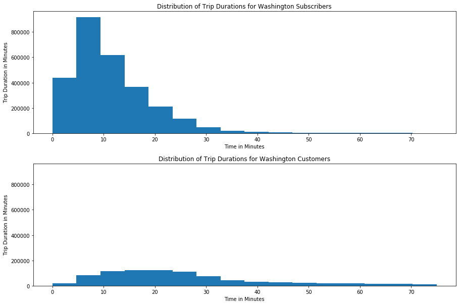

```python
f, (plt1, plt2) = plt.subplots(2, sharey=True)
plt1.hist(trip_times_subs_washington, range = (0, 75), bins = 16)
plt1.set_title('Distribution of Trip Durations for Washington Subscribers')
plt1.set_xlabel('Time in Minutes')
plt1.set_ylabel("Trip Duration in Minutes")


plt2.hist(trip_times_cust_washington, range = (0, 75), bins = 16)
plt2.set_title('Distribution of Trip Durations for Washington Customers')
plt2.set_xlabel('Time in Minutes')
plt2.set_ylabel("Trip Duration in Minutes")


f.subplots_adjust(hspace=0.25)
f.set_figheight(10)
f.set_figwidth(15)
plt.show()
```

**Distribution of trip duration for different type of users on chicago**

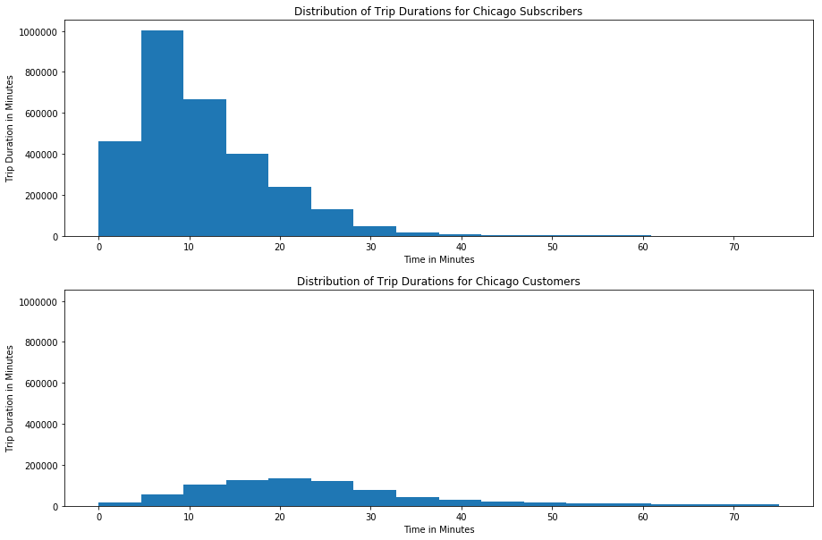

```python
f, (plt1, plt2) = plt.subplots(2, sharey=True)
plt1.hist(trip_times_subs_chicago, range = (0, 75), bins = 16)
plt1.set_title('Distribution of Trip Durations for Chicago Subscribers')
plt1.set_xlabel('Time in Minutes')
plt1.set_ylabel("Trip Duration in Minutes")

plt2.hist(trip_times_cust_chicago, range = (0, 75), bins = 16)
plt2.set_title('Distribution of Trip Durations for Chicago Customers')
plt2.set_xlabel('Time in Minutes')
plt2.set_ylabel("Trip Duration in Minutes")

f.subplots_adjust(hspace=0.25)
f.set_figheight(10)
f.set_figwidth(15)
plt.show()
```

**Distribution of trip duration for different type of users on nyc**

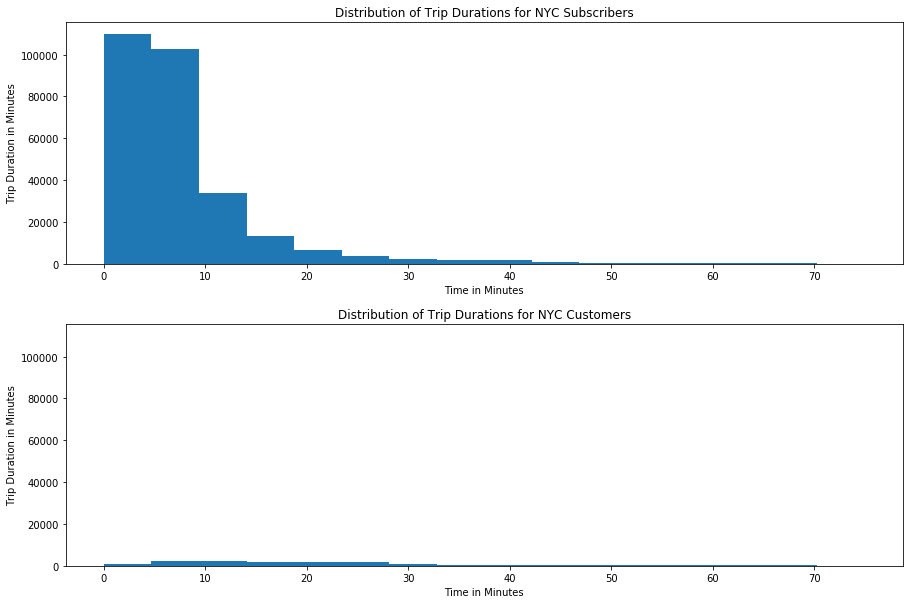

```python
f, (plt1, plt2) = plt.subplots(2, sharey=True)
plt1.hist(trip_times_subs_nyc, range = (0, 75), bins = 16)
plt1.set_title('Distribution of Trip Durations for NYC Subscribers')
plt1.set_xlabel('Time in Minutes')
plt1.set_ylabel("Trip Duration in Minutes")

plt2.hist(trip_times_cust_nyc, range = (0, 75), bins = 16)
plt2.set_title('Distribution of Trip Durations for NYC Customers')
plt2.set_xlabel('Time in Minutes')
plt2.set_ylabel("Trip Duration in Minutes")

f.subplots_adjust(hspace=0.25)
f.set_figheight(10)
f.set_figwidth(15)
plt.show()
```

# Exera analysis for Washington

#### Exera analysis for Washington

how many trips per month with different types of users?  
what is the ratio per month of subscriber trips to the customer trips?

```
Subscriber Trips by Month => {1: 152934, 2: 182281, 3: 193219, 4: 241750, 5: 241914, 6: 279723, 7: 258919, 8: 280687, 9: 285589, 10: 290954, 11: 210223, 12: 157786}
Customer Trips by Month => {1: 21870, 2: 44022, 3: 52184, 4: 124240, 5: 97763, 6: 119028, 7: 138761, 8: 121847, 9: 105782, 10: 93879, 11: 42311, 12: 20111}
```

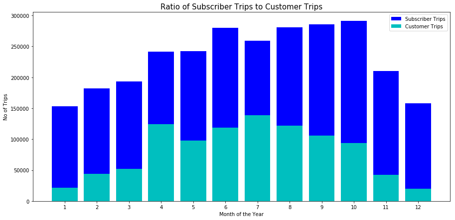

```
Ratio of Subscriber to Customer Trips => {1: 6.99, 2: 4.14, 3: 3.7, 4: 1.95, 5: 2.47, 6: 2.35, 7: 1.87, 8: 2.3, 9: 2.7, 10: 3.1, 11: 4.97, 12: 7.85}
```

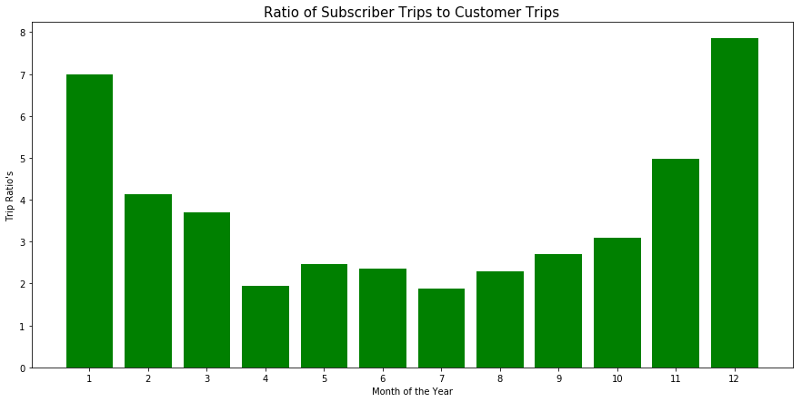

```python
def trips_by_month(filename, user_type):
    with open(filename, 'r') as f_in:

        reader = csv.DictReader(f_in)
        trips_month = {1:0, 2:0, 3:0, 4: 0, 5:0, 6:0, 7:0, 8:0, 9:0, 10:0, 11:0, 12:0}
        for row in reader:
            if user_type == 'Subscriber' and row['user_type'] == 'Subscriber':
                trips_month[int(row['month'])] += 1
            elif user_type == 'Customer' and row['user_type'] == 'Customer':
                trips_month[int(row['month'])] += 1
        return (trips_month)


trips_month_subs = trips_by_month(data_file_Washington, 'Subscriber')
print("Subscriber Trips by Month => " + str(trips_month_subs))

trips_month_cust = trips_by_month(data_file_Washington, 'Customer')
print("Customer Trips by Month => " + str(trips_month_cust))

no_of_months = range(12)
plt.figure(figsize=(15,7))
plt.bar(no_of_months, trips_month_subs.values(), color='b', align='center')
plt.bar(no_of_months, trips_month_cust.values(), color='c', align='center')
plt.legend(('Subscriber Trips','Customer Trips'))
plt.xticks(no_of_months, trips_month_subs.keys())
plt.xlabel("Month of the Year")
plt.ylabel("No of Trips")
plt.title("Ratio of Subscriber Trips to Customer Trips", fontsize=15)
plt.show()

# Get the Ratio of Subscriber Trips to Customer Trips
ratio_of_trips = {mon: round(trips_month_subs[mon]/trips_month_cust[mon],2) for mon in trips_month_subs}
print("Ratio of Subscriber to Customer Trips => " + str(ratio_of_trips))

no_of_months = range(12)
plt.figure(figsize=(15,7))
plt.bar(no_of_months, ratio_of_trips.values(), color='g', align='center')
plt.xticks(no_of_months, ratio_of_trips.keys())
plt.xlabel('Month of the Year')
plt.ylabel("Trip Ratio's")
plt.title("Ratio of Subscriber Trips to Customer Trips", fontsize=15)
plt.show()
```

what is the distribution over weekends?  
what is the distribution over weekdays

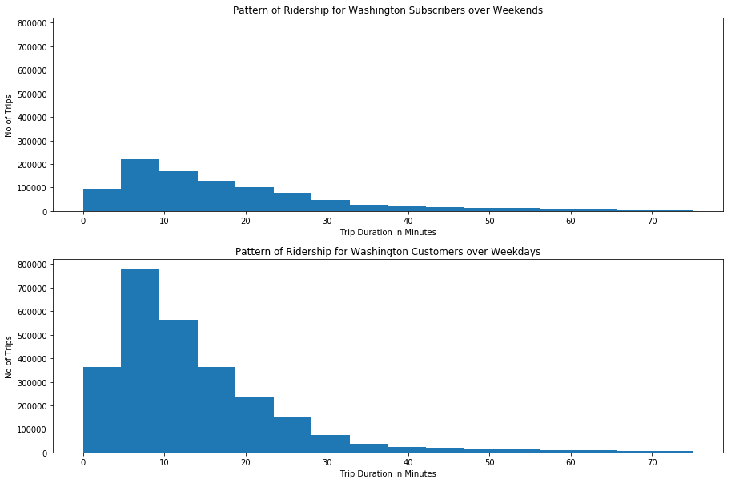

```python
def trips_by_day_of_week(filename):
    with open(filename, 'r') as f_in:
        reader = csv.DictReader(f_in)
        weekend_duration = []
        weekend_no_of_rides = 0
        weekday_duration = []
        weekday_no_of_rides = 0
        for row in reader:
            if row['day_of_week'] == 'Saturday' or row['day_of_week'] == 'Sunday':
                weekend_duration.append(float(row['duration']))
                weekend_no_of_rides += 1
            else:
                weekday_duration.append(float(row['duration']))
                weekday_no_of_rides += 1
        return (weekend_duration, weekend_no_of_rides, weekday_duration, weekday_no_of_rides)



weekend_duration, weekend_no_of_rides, weekday_duration, weekday_no_of_rides = trips_by_day_of_week(data_file_Washington)
f, (plt1, plt2) = plt.subplots(2, sharey=True)
plt1.hist(weekend_duration, range = (0, 75), bins = 16)
plt1.set_title('Pattern of Ridership for Washington Subscribers over Weekends')
plt1.set_xlabel('Trip Duration in Minutes')
plt1.set_ylabel("No of Trips")

plt2.hist(weekday_duration, range = (0, 75), bins = 16)
plt2.set_title('Pattern of Ridership for Washington Customers over Weekdays')
plt2.set_xlabel('Trip Duration in Minutes')
plt2.set_ylabel("No of Trips")

f.subplots_adjust(hspace=0.25)
f.set_figheight(10)
f.set_figwidth(15)
plt.show()
```

**what is the distribution of different types of users over the days of the week ?**

```
Subscriber Trips by Day of Week => {1: 401428, 2: 449036, 3: 474664, 4: 451826, 5: 416427, 6: 295413, 7: 287185}
Customer Trips by Day of Week => {1: 115854, 2: 102200, 3: 98237, 4: 99884, 5: 124609, 6: 225332, 7: 215682}
```

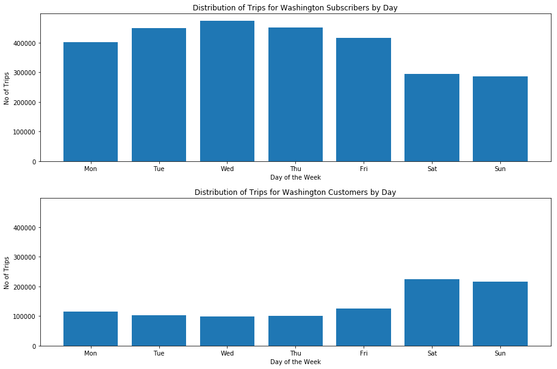

```python
#here to see in what type of distribution of trips over the week by what type of users

def trips_by_day(filename, user_type):
    with open(filename, 'r') as f_in:
        reader = csv.DictReader(f_in)
        days_of_week = {'Monday':1, 'Tuesday':2, 'Wednesday':3, 'Thursday':4, 'Friday':5, 'Saturday':6, 'Sunday':7}
        trips_day_of_week = {1:0, 2:0, 3:0, 4:0, 5:0, 6:0, 7:0}
        for row in reader:
            if user_type == 'Subscriber' and row['user_type'] == 'Subscriber':
                trips_day_of_week[days_of_week[row['day_of_week']]] += 1
            elif user_type == 'Customer' and row['user_type'] == 'Customer':
                trips_day_of_week[days_of_week[row['day_of_week']]] += 1
        return (trips_day_of_week)

day_of_weeks_list = ['Mon', 'Tue', 'Wed', 'Thu', 'Fri', 'Sat', 'Sun']
trips_day_of_week_subs = trips_by_day(data_file_Washington, 'Subscriber')
print("Subscriber Trips by Day of Week => " + str(trips_day_of_week_subs))
trips_day_of_week_cust = trips_by_day(data_file_Washington, 'Customer')
print("Customer Trips by Day of Week => " + str(trips_day_of_week_cust))


f, (plt1, plt2) = plt.subplots(2, sharey=True)
plt1.bar(list(trips_day_of_week_subs.keys()), trips_day_of_week_subs.values())
plt1.set_xticks(list(trips_day_of_week_subs.keys()))
plt1.set_xticklabels(['Mon', 'Tue', 'Wed', 'Thu', 'Fri', 'Sat', 'Sun'])
plt1.set_xlabel("Day of the Week")
plt1.set_ylabel('No of Trips')
plt1.set_title('Distribution of Trips for Washington Subscribers by Day')

plt2.bar(list(trips_day_of_week_cust.keys()), trips_day_of_week_cust.values())
plt2.set_xticks(list(trips_day_of_week_cust.keys()))
plt2.set_xticklabels(['Mon', 'Tue', 'Wed', 'Thu', 'Fri', 'Sat', 'Sun'])
plt2.set_xlabel("Day of the Week")
plt2.set_ylabel('No of Trips')
plt2.set_title('Distribution of Trips for Washington Customers by Day')

f.subplots_adjust(hspace=0.25)
f.set_figheight(10)
f.set_figwidth(15)
plt.show()
```

# Conclusions

#### Conclusions

bike share system is growing system and i hope this notebook is useful for whom are not know any information about the system